# Droughts - Pre-Processing

In this notebook, I will be going over the preprocessing steps needed before starting the experiments. I will include the following steps:

1. Load Data
2. Select California
3. Fill NANs
4. Smoothing of the VOD signal (savgol filter)
5. Removing the climatology
6. Select drought years and non-drought years
7. Extract density cubes

## Code

```
import sys, os
cwd = os.getcwd()
sys.path.insert(0, f'{cwd}/../../')
sys.path.insert(0, '/home/emmanuel/code/py_esdc')


import xarray as xr
import pandas as pd
import numpy as np

# drought tools
from src.data.drought.loader import DataLoader
from src.features.drought.build_features import (
    get_cali_geometry,
    mask_datacube,
    smooth_vod_signal,
    remove_climatology,
    get_cali_emdata,
    get_drought_years,
    get_density_cubes,
    get_common_elements,
    normalize
)
from src.visualization.drought.analysis import plot_mean_time

# esdc tools
from esdc.subset import select_pixel
from esdc.shape import ShapeFileExtract, rasterize
from esdc.transform import DensityCubes

import matplotlib.pyplot as plt
import cartopy
import cartopy.crs as ccrs
plt.style.use(['fivethirtyeight', 'seaborn-poster'])
%matplotlib inline

%load_ext autoreload
%autoreload 2
```

## 1. Load Data

```
region = 'conus'
sampling = '14D'

drought_cube = DataLoader().load_data(region, sampling)


pixel = (-121, 37)

drought_cube
```

```
<xarray.Dataset>
Dimensions:  (lat: 461, lon: 865, time: 146)
Coordinates:
  * lat      (lat) float64 25.88 25.93 25.98 26.03 ... 48.74 48.79 48.84 48.89
  * lon      (lon) float64 -124.4 -124.3 -124.2 -124.2 ... -80.64 -80.59 -80.54
  * time     (time) datetime64[ns] 2010-06-01 2010-06-15 ... 2015-12-22
Data variables:
    SMADI    (lat, lon, time) float64 ...
    LST      (lat, lon, time) float64 ...
    NDVI     (lat, lon, time) float64 ...
    VOD      (lat, lon, time) float64 ...
    SM       (lat, lon, time) float64 ...
```

Verify with a simple plot.

```
plot_mean_time(
    drought_cube.LST.sel(time=slice('June-2010', 'June-2010'))
)
```

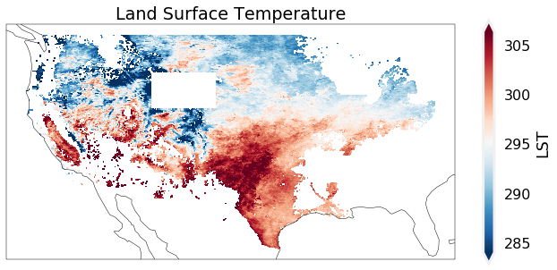

## 2. Subset California

```
# get california polygon
cali_geoms = get_cali_geometry()

# get california cube subset
cali_cube = mask_datacube(drought_cube, cali_geoms)
```

```
plot_mean_time(
    cali_cube.LST.sel(time=slice('June-2011', 'June-2011'))
)
```

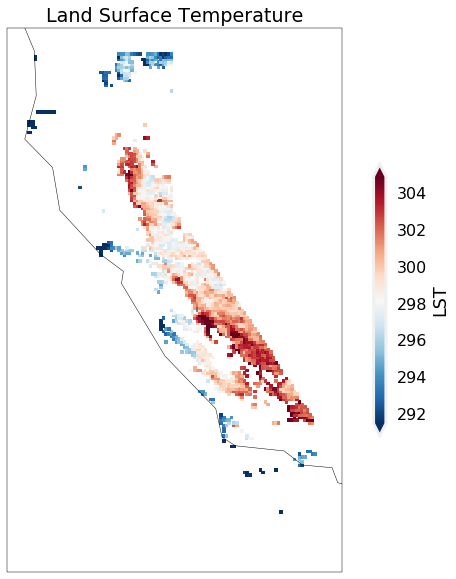

## 3. Interpolate NANs - Time Dimension

```
# interpolation arguments
interp_dim = 'time'
method = 'linear'

# do interpolation
cali_cube_interp = cali_cube.interpolate_na(
    dim=interp_dim,
    method=method
)
```

## 4. Smoothing the Signal (VOD)

In this section, we will try to smooth the signal with two methods:

1. Simple - Rolling mean
2. Using a savgol filter.

Some initial parameters:

- Window Size = 5
- Polynomial Order = 3

We will apply this filter in the time domain only.

```
vod_data = cali_cube_interp.VOD
vod_data
```

```
<xarray.DataArray 'VOD' (lat: 189, lon: 103, time: 146)>
array([[[nan, nan, nan, ..., nan, nan, nan],
        [nan, nan, nan, ..., nan, nan, nan],
        [nan, nan, nan, ..., nan, nan, nan],
        ...,
        [nan, nan, nan, ..., nan, nan, nan],
        [nan, nan, nan, ..., nan, nan, nan],
        [nan, nan, nan, ..., nan, nan, nan]],

       [[nan, nan, nan, ..., nan, nan, nan],
        [nan, nan, nan, ..., nan, nan, nan],
        [nan, nan, nan, ..., nan, nan, nan],
        ...,
        [nan, nan, nan, ..., nan, nan, nan],
        [nan, nan, nan, ..., nan, nan, nan],
        [nan, nan, nan, ..., nan, nan, nan]],

       [[nan, nan, nan, ..., nan, nan, nan],
        [nan, nan, nan, ..., nan, nan, nan],
        [nan, nan, nan, ..., nan, nan, nan],
        ...,
        [nan, nan, nan, ..., nan, nan, nan],
        [nan, nan, nan, ..., nan, nan, nan],
        [nan, nan, nan, ..., nan, nan, nan]],

       ...,

       [[nan, nan, nan, ..., nan, nan, nan],
        [nan, nan, nan, ..., nan, nan, nan],
        [nan, nan, nan, ..., nan, nan, nan],
        ...,
        [nan, nan, nan, ..., nan, nan, nan],
        [nan, nan, nan, ..., nan, nan, nan],
        [nan, nan, nan, ..., nan, nan, nan]],

       [[nan, nan, nan, ..., nan, nan, nan],
        [nan, nan, nan, ..., nan, nan, nan],
        [nan, nan, nan, ..., nan, nan, nan],
        ...,
        [nan, nan, nan, ..., nan, nan, nan],
        [nan, nan, nan, ..., nan, nan, nan],
        [nan, nan, nan, ..., nan, nan, nan]],

       [[nan, nan, nan, ..., nan, nan, nan],
        [nan, nan, nan, ..., nan, nan, nan],
        [nan, nan, nan, ..., nan, nan, nan],
        ...,
        [nan, nan, nan, ..., nan, nan, nan],
        [nan, nan, nan, ..., nan, nan, nan],
        [nan, nan, nan, ..., nan, nan, nan]]])
Coordinates:
  * lat      (lat) float64 32.53 32.58 32.63 32.68 ... 41.79 41.84 41.89 41.94
  * lon      (lon) float64 -124.4 -124.3 -124.2 -124.2 ... -118.7 -118.7 -118.6
  * time     (time) datetime64[ns] 2010-06-01 2010-06-15 ... 2015-12-22
```

### 4.1 - Savgol Filter

```
from scipy.signal import savgol_filter
```

```
# select example
vod_data_ex = select_pixel(vod_data, pixel)

# savgol filter params
window_length = 5
polyorder = 3

# apply savgol filter
vod_smooth_filter = savgol_filter(
    vod_data_ex,
    window_length=window_length,
    polyorder=polyorder
)

fig, ax = plt.subplots(nrows=2, figsize=(10, 10))

ax[0].plot(vod_data_ex)
ax[0].set_title('Original Data')

ax[1].plot(vod_smooth_filter)
ax[1].set_title('After Savgol Filter')
plt.show()
```

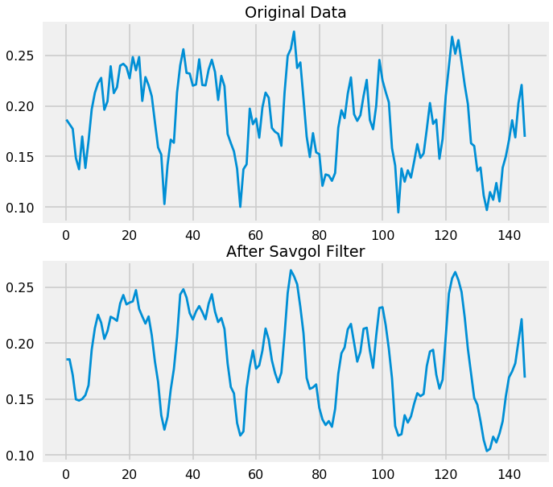

### 4.2 - Rolling Window

```
# select example
vod_data_ex = select_pixel(vod_data, pixel)

# savgol filter params
window_length = 2

# apply savgol filter
vod_smooth_roll = vod_data_ex.rolling(
    time=window_length,
    center=True
).mean()

fig, ax = plt.subplots(nrows=2, figsize=(10, 10))

ax[0].plot(vod_data_ex)
ax[0].set_title('Original Data')

ax[1].plot(vod_smooth_roll)
ax[1].set_title('After Rolling Mean')
plt.show()
```

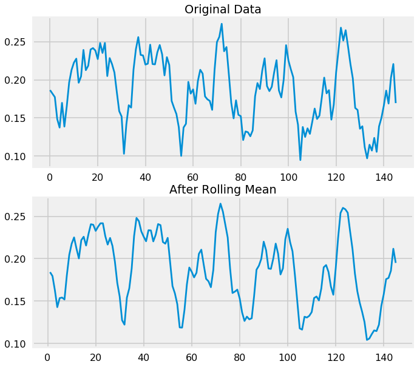

### 4.3 - Difference

```
vod_smooth_diff = vod_smooth_filter - vod_smooth_roll
```

```
fig, ax = plt.subplots(nrows=4,figsize=(10,10))



ax[0].plot(vod_data_ex)
ax[0].set_title('Original')

ax[1].plot(vod_smooth_filter)
ax[1].set_title('Savgol Filter')

ax[2].plot(vod_smooth_roll)
ax[2].set_title('Rolling Mean')

ax[3].plot(vod_smooth_diff)
ax[3].set_title('Difference')

# Scale the Difference Y-Limits
ymax = np.max([vod_smooth_filter.max(), vod_smooth_roll.max()])
ymin = np.min([vod_smooth_filter.min(), vod_smooth_roll.min()])
center = (ymax - ymin)
ymax = ymax - center
ymin = center - ymin

ax[3].set_ylim([0 - ymin, 0 + ymax])

plt.tight_layout()
plt.show()
```

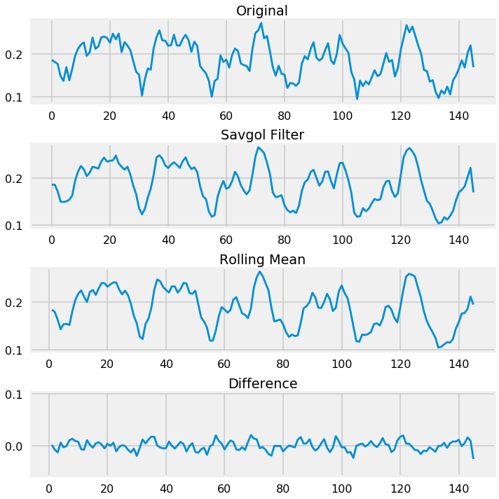

### 4.3 - Apply Rolling Mean to the whole dataset

```
cali_cube_interp = smooth_vod_signal(cali_cube_interp, window_length=2, center=True)
```

## 5. Remove Climatology

When I mean 'climatology', I mean the difference between observations and typical weather for a particular season. The anomalies should not show up in the seasonal cycle. I'll just do a very simple removal. I'll calculate the monthly mean wrt time and then remove that from each month from the original datacube.

**Steps**

1. Climatalogy - Monthly Mean for the 6 years
2. Remove Climatology - Climatology from each month

```
# remove climatology
cali_anomalies, cali_mean = remove_climatology(cali_cube_interp)
```

Simple check where we look at the original and the new.

```
variables = ['LST', 'VOD', 'NDVI', 'SM']

for ivariable in variables:

    fig, ax = plt.subplots(nrows=3, figsize=(10, 10))

    # Before Climatology
    select_pixel(cali_cube_interp[ivariable], pixel).plot(ax=ax[0])
    ax[0].set_title('Original Time Series')

    # Climatology
    select_pixel(cali_mean[ivariable], pixel).plot(ax=ax[1])
    ax[1].set_title('Climatology')

    # After Climatology
    select_pixel(cali_anomalies[ivariable], pixel).plot(ax=ax[2])
    ax[2].set_title('After Climatology Median Removed')
    plt.tight_layout()
    plt.show()
```

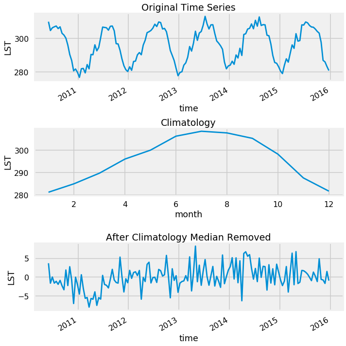

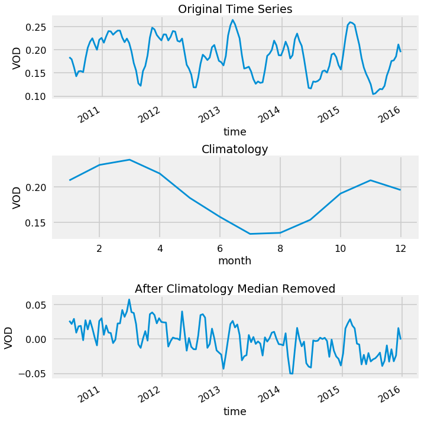

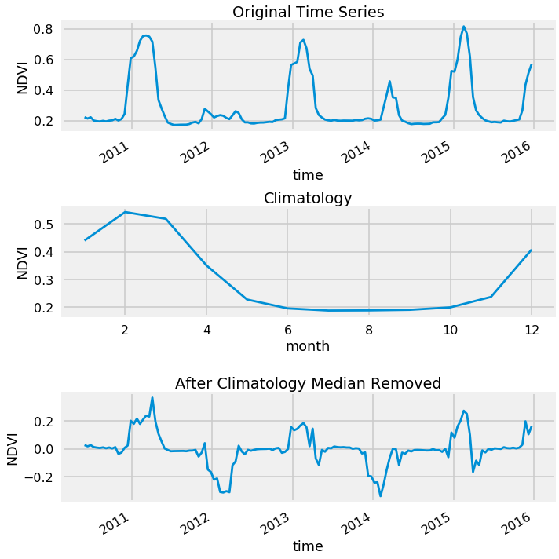

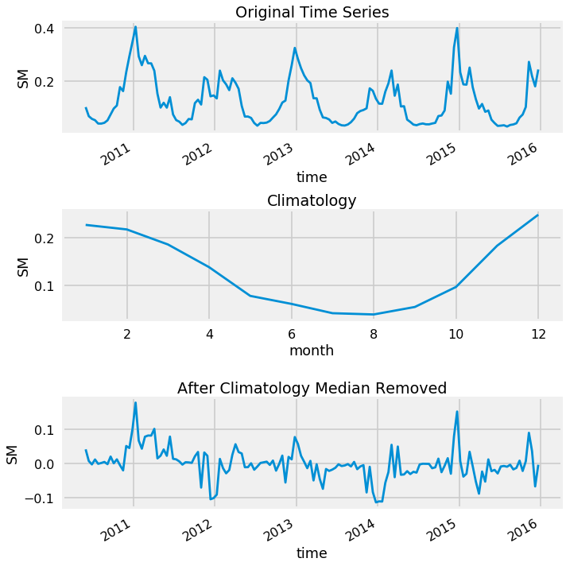

## 6. EMData

I extract the dates for the drought events for california. This will allow me to separate the drought years and non-drought years.

```
cali_droughts = get_cali_emdata()
cali_droughts
```

|  | ID | ISO | LOCATION | Date_Start | Date_End | UTC_Start | UTC_End | geometry |
| --- | --- | --- | --- | --- | --- | --- | --- | --- |
| 105 | 106 | USA | California | 01-Jun-2012 | 31-Dec-2012 | 735021 | 735234 | (POLYGON ((-117.2328491210938 32.7764053344726... |
| 132 | 133 | USA | California | 01-Jan-2014 | 31-Dec-2014 | 735600 | 735964 | (POLYGON ((-117.2328491210938 32.7764053344726... |
| 153 | 154 | USA | California | 01-Jan-2015 | 31-Dec-2015 | 735965 | 736329 | (POLYGON ((-117.2328491210938 32.7764053344726... |

So the drought years are:

**Drought Years**

- 2012
- 2014
- 2015

**Non-Drought Years**

- 2010
- 2011
- 2013

**Note**: Even though the EM-Data says that the drought year for 2012 is only half a year, we're going to say that that is a full year.

```
# Drought Years
cali_anomalies_drought = get_drought_years(
    cali_anomalies, ['2012', '2014', '2015']
)

# Non-Drought Years
cali_anomalies_nondrought = get_drought_years(
    cali_anomalies, ['2010', '2011', '2013']
)
```

## 7. Extract Density Cubes

In this step, we will construct 'density cubes'. These are cubes where we add features from a combination of the spatial and/or temporal dimensions. Instead of a single sample, we have a sample that takes into account spatial and/or temporal information. In this experiment, we will only look at temporal information. Our temporal resolution is 14 Days and we want to look at a maximum of 6 months.

So:

```
# confirm
sub_ = cali_anomalies_drought.isel(time=slice(0,12))

sub_.time[0].data, sub_.time[-1].data
```

```
(array('2012-01-10T00:00:00.000000000', dtype='datetime64[ns]'),
 array('2012-06-12T00:00:00.000000000', dtype='datetime64[ns]'))
```

We see that the start date for the year 2012 is 01-10 and the end date is 06-12. It's good enough. So we get roughly 6 months of temporal information in our density cubes.

#### 7.1 - Example Density Cube

```
# window sizes
spatial = 1
time = 12

vod_df, lst_df, ndvi_df, sm_df = get_density_cubes(cali_anomalies_drought, spatial, time)
vod_df.shape, lst_df.shape, ndvi_df.shape, sm_df.shape
```

```
((76690, 12), (85995, 12), (82729, 12), (76690, 12))
```

### 8. Find Common Elements

Notice how the number of elements is different depending upon the dataset. I believe it is the case that there are less elements for the VOD and the SM datasets. To make a fair comparison, I'll be using only the common elements between the two density cubes.

**Note**: This is also a bit difficult for RBIG to calculate the Mutual Information for datasets that are potentially so different in their domain.

```
vod_df, lst_df = get_common_elements(vod_df, lst_df)
```

```
vod_df.shape, lst_df.shape
```

```
((76690, 12), (76690, 12))
```